# Course Project Write Up

Coursera KKParker

December 22, 2015

# Executive Summary

In this report, a human activity recognition dataset was used to predict a weight lifting activity by a user. The data were split in to training and testing data sets. Predictors were pruned in order to remove variables that did not have a variety or values and those that were missing a lot of values. In addition, the variables were standardized. A CART model, bagging tree model, and linear discriminant model were used to predict the activity class. The Bagging tree model proved to be the best for this dataset with a 99.9% accuracy on the training dataset. In addition, all 20 of the test dataset points were accurately predicted.

# Introduction

With the increased used of activity trackers such as the Fit Bit and Vivofit, we have seen an increase in the ability of a computer to recognize and classify what a human is doing. This area of study is called *human activity recognition*. The trackers collect data such as vertical and horizonal movements and try to classify subjects as sleeping, walking, running, or walking up the stairs.

# Data Set

This study examines a dataset from a study by Velloso, Bulling, Gellersen, Ugulino, and Fuks (see citation at the end of the report: http://groupware.les.inf.puc-rio.br/har#ixzz3v4M2P3qT). It is weight lifting data as a study . In the study, six subjects performed 10 replications of five different bicep curls:

*A-correctly*  
B-throwing elbows to front  
*C-lifting dumbbell only half way*  
D-lowering dumbbell only half way  
*E-throwing hips to front

In our analysis, the variable classe contains this target variable for our model which holds the values: A, B, C, D or E.

## Loading the data

Let’s begin by reading in the Training and Testing Data.

```r
pmltrain <- read.csv('C:/Temp/pml-training.csv')
pmltest <- read.csv('C:/Temp/pml-testing.csv')
dim(pmltrain)
```

```
## [1] 19622   160
```

We can see we have 160 variables and there are 19,622 observations or recordings from these subjects performing these activities.

# Setting up r and the environment

Let’s set up markdown to cache the r code to help with the speed of running our program.

We will begin by loading the caret and kernlab packages. The caret package (Classification and Regression Training) allows us to perform predictive modeling as well as has options for preprocessing, model tuning with resampling, and variable importance estimation.

```r
library(caret); library(kernlab)
```

## Removing variables with little variance

Now, let’s look for variables with little or no variance. If the variables are mostly the same values, then they will not help us predict the activity classe. We will use caret’s nearZeroVar function that identifies variables with little variance.

```r
nzv <- nearZeroVar(pmltrain,saveMetrics=TRUE)
removenzvvar <- row.names(subset(nzv,nzv == TRUE))
length(removenzvvar)
```

```
## [1] 60
```

So we have 60 variables with little variance, so let’s begin our preprocessing by removing these variables from contention as predictors so we have 100 variables left in the data set.

```r
pmltrain2 <- pmltrain[,!names(pmltrain) %in% removenzvvar]
```

## Examining the target variable

Next, let’s begin to look at our target variable, the classe.

```r
table(pmltrain2$classe)
```

```
##
##    A    B    C    D    E
## 5580 3797 3422 3216 3607
```

From this table we can see there are 5 different classes as we expected.

## Examining the remainder of our predictors

Next, let’s start to examine our predictors. X is an index so we won’t use it as a predictor

```r
table(pmltrain2$user_name)
```

```
##
##   adelmo carlitos  charles   eurico   jeremy    pedro
##     3892     3112     3536     3070     3402     2610
```

We can see we have 6 users who are being monitored in the user_name column. This is probably very useful information. We have between 2610 to 3892 observations across users. Let’s see how each person distributes across the classes

```r
table(pmltrain2$user_name,pmltrain2$classe)
```

```
##
##               A    B    C    D    E
##   adelmo   1165  776  750  515  686
##   carlitos  834  690  493  486  609
##   charles   899  745  539  642  711
##   eurico    865  592  489  582  542
##   jeremy   1177  489  652  522  562
##   pedro     640  505  499  469  497
```

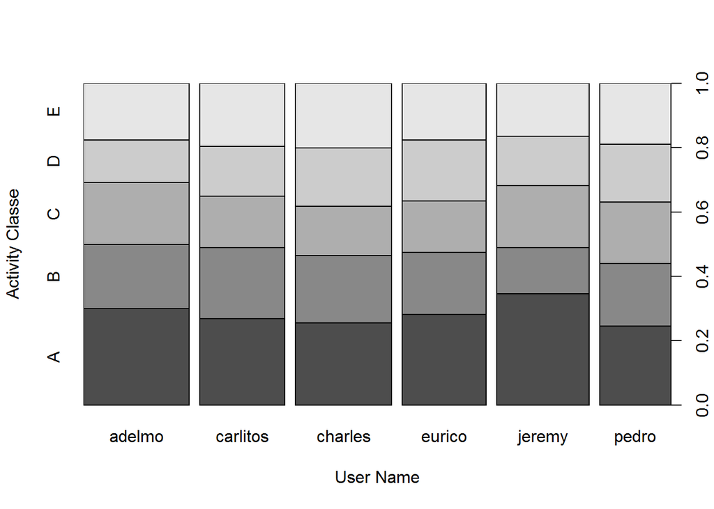

```r
plot(pmltrain2$classe~pmltrain2$user_name, xlab="User Name", ylab="Activity Classe")
```

We can see that classe A (correct execution) had the largest proportion for all users and they did all complete all classes of activities.

Lets ignore the 3 time variables (raw_timestamp_part_1, raw_timestamp_part_2, and cvtd_timestamp) since we can’t use them with our test data since we have single observations.

What is num_window?

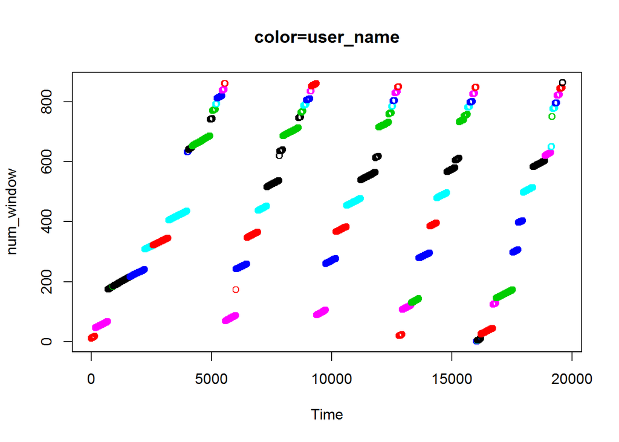

```r
plot(pmltrain2$X,pmltrain2$num_window,col=pmltrain2$user_name,main="color=user_name", xlab="Time", ylab="num_window")
```

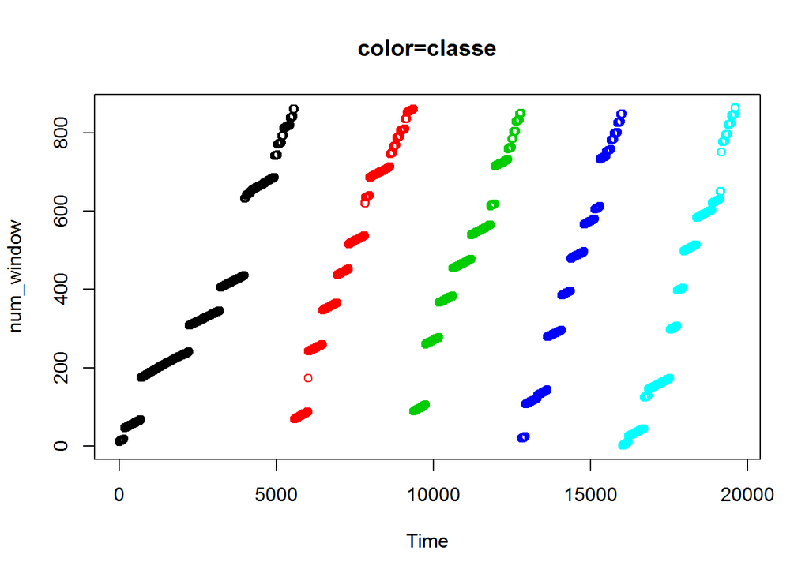

```r
plot(pmltrain2$X,pmltrain2$num_window,col=pmltrain2$classe, main="color=classe",xlab="Time", ylab="num_window")
```

This variable num_window appears to be a counter so I will not include it as a predictor. So let’s remove the 3 time variables and num_window.

```r
pmltrain2 <- pmltrain2[,!names(pmltrain2) %in% c("num_window", "raw_timestamp_part_1", "raw_timestamp_part_2","cvtd_timestamp")]
```

## Removing Missing Values

The remainder of the variables appear to be the measurements so we will now attempt to look for variables with too many missing values.

```r
M <- sapply(pmltrain2, function(x) sum(is.na(x)))
removemissvar <- names(M[M>0])
length(removemissvar)
```

```
## [1] 41
```

```r
pmltrain2 <- pmltrain2[,!names(pmltrain2) %in% removemissvar]
```

We have removed the 41 variables with too many missing values. This leaves use with 53 variables that we will use as predictors. These variables were taken from 4 sensors on the user and the dumbell. In the dataset they are represented by the following:

*sensor glove: _forearm  
*sensor armband: _arm  
*sensor lumbar belt: _belt  
*sensor dumbbell: _dumbbell

## Creating the training dataset

We will use ptrain as our training dataset. It has 53 numeric and integer variables and it also has the target variable classe. Note we are removing the X index variable.

```r
ptrain <- subset(pmltrain2, select=-c(X))
rownames(ptrain) <- 1:nrow(ptrain)
```

## Standardizing the numeric predictors

We know that standardizing the numeric data will help with prediction. So let’s standardize the numeric and integer variables (all those left except user_name and classe).

```r
ptrainvarnum <- subset(ptrain,select=-c(user_name,classe))
preObjStd <- preProcess(ptrainvarnum,method=c("center","scale"))
ptrainpreprocStd <- predict(preObjStd,ptrainvarnum)
ptrainwStd <- data.frame(cbind(data.frame(ptrain$classe),data.frame(ptrain$user_name)))
names(ptrainwStd) <- c("classe","user_name")
ptrainwStd <- cbind(ptrainwStd,ptrainpreprocStd)
head(ptrain$roll_belt)
```

```
## [1] 1.41 1.41 1.42 1.48 1.48 1.45
```

```r
head(ptrainwStd$roll_belt)
```

```
## [1] -1.003935 -1.003935 -1.003776 -1.002820 -1.002820 -1.003298
```

We can see how roll_belt is different for the original training and standardized training datasets.

# Model Building

## CART model (recursiving partitioning)

Let’s try to fit a CART classification model predicting classe with the 53 remaining variables.

```r
library(rpart)
modFit_rpart<- train(classe ~., data=ptrain, method="rpart")
modFit_rpart
```

```
## CART
##
## 19622 samples
##    53 predictor
##     5 classes: 'A', 'B', 'C', 'D', 'E'
##
## No pre-processing
## Resampling: Bootstrapped (25 reps)
## Summary of sample sizes: 19622, 19622, 19622, 19622, 19622, 19622, ...
## Resampling results across tuning parameters:
##
##   cp          Accuracy   Kappa      Accuracy SD  Kappa SD
##   0.03567868  0.5159986  0.3709040  0.01752583   0.02893057
##   0.05998671  0.3863288  0.1598415  0.04747216   0.07930599
##   0.11515454  0.3187523  0.0543323  0.04231701   0.06257949
##
## Accuracy was used to select the optimal model using  the largest value.
## The final value used for the model was cp = 0.03567868.
```

```r
predictions <- predict(modFit_rpart, newdata=ptrain)
confusionMatrix(predictions,ptrain$classe)
```

```
## Confusion Matrix and Statistics
##
##           Reference
## Prediction    A    B    C    D    E
##          A 5080 1581 1587 1449  524
##          B   81 1286  108  568  486
##          C  405  930 1727 1199  966
##          D    0    0    0    0    0
##          E   14    0    0    0 1631
##
## Overall Statistics
##
##                Accuracy : 0.4956
##                  95% CI : (0.4885, 0.5026)
##     No Information Rate : 0.2844
##     P-Value [Acc > NIR] : < 2.2e-16
##
##                   Kappa : 0.3407
##  Mcnemar's Test P-Value : NA
##
## Statistics by Class:
##
##                      Class: A Class: B Class: C Class: D Class: E
## Sensitivity            0.9104  0.33869  0.50468   0.0000  0.45218
## Specificity            0.6339  0.92145  0.78395   1.0000  0.99913
## Pos Pred Value         0.4970  0.50850  0.33040      NaN  0.99149
## Neg Pred Value         0.9468  0.85310  0.88225   0.8361  0.89008
## Prevalence             0.2844  0.19351  0.17440   0.1639  0.18382
## Detection Rate         0.2589  0.06554  0.08801   0.0000  0.08312
## Detection Prevalence   0.5209  0.12889  0.26638   0.0000  0.08383
## Balanced Accuracy      0.7721  0.63007  0.64431   0.5000  0.72565
```

## Bagging Model

Let’s see if we can improve the model with the bagging option since the accuracy is quite poor at 49%.

```r
library(ipred)
modFit_treebag<- train(classe ~., data=ptrain, method="treebag")
modFit_treebag
```

```
## Bagged CART
##
## 19622 samples
##    53 predictor
##     5 classes: 'A', 'B', 'C', 'D', 'E'
##
## No pre-processing
## Resampling: Bootstrapped (25 reps)
## Summary of sample sizes: 19622, 19622, 19622, 19622, 19622, 19622, ...
## Resampling results
##
##   Accuracy   Kappa      Accuracy SD  Kappa SD
##   0.9843616  0.9802103  0.003367512  0.004264359
##
##
```

```r
predictions <- predict(modFit_treebag, newdata=ptrain)
confusionMatrix(predictions,ptrain$classe)
```

```
## Confusion Matrix and Statistics
##
##           Reference
## Prediction    A    B    C    D    E
##          A 5580    1    0    0    0
##          B    0 3795    0    0    0
##          C    0    1 3422    6    1
##          D    0    0    0 3210    0
##          E    0    0    0    0 3606
##
## Overall Statistics
##
##                Accuracy : 0.9995
##                  95% CI : (0.9991, 0.9998)
##     No Information Rate : 0.2844
##     P-Value [Acc > NIR] : < 2.2e-16
##
##                   Kappa : 0.9994
##  Mcnemar's Test P-Value : NA
##
## Statistics by Class:
##
##                      Class: A Class: B Class: C Class: D Class: E
## Sensitivity            1.0000   0.9995   1.0000   0.9981   0.9997
## Specificity            0.9999   1.0000   0.9995   1.0000   1.0000
## Pos Pred Value         0.9998   1.0000   0.9977   1.0000   1.0000
## Neg Pred Value         1.0000   0.9999   1.0000   0.9996   0.9999
## Prevalence             0.2844   0.1935   0.1744   0.1639   0.1838
## Detection Rate         0.2844   0.1934   0.1744   0.1636   0.1838
## Detection Prevalence   0.2844   0.1934   0.1748   0.1636   0.1838
## Balanced Accuracy      1.0000   0.9997   0.9998   0.9991   0.9999
```

The accuracy of this model is remarkably better than the simple CART model at 99.9% for our training data.

## Linear Discriminant Analysis

Just for reference, let’s also try a Linear Discriminant Model.

```r
modFit_lda<- train(classe ~., data=ptrain, method="lda")
modFit_lda
```

```
## Linear Discriminant Analysis
##
## 19622 samples
##    53 predictor
##     5 classes: 'A', 'B', 'C', 'D', 'E'
##
## No pre-processing
## Resampling: Bootstrapped (25 reps)
## Summary of sample sizes: 19622, 19622, 19622, 19622, 19622, 19622, ...
## Resampling results
##
##   Accuracy   Kappa      Accuracy SD  Kappa SD
##   0.7322765  0.6609413  0.004262424  0.005433567
##
##
```

```r
predictions <- predict(modFit_lda, newdata=ptrain)
confusionMatrix(predictions,ptrain$classe)
```

```
## Confusion Matrix and Statistics
##
##           Reference
## Prediction    A    B    C    D    E
##          A 4689  591  330  204  116
##          B  128 2464  317  115  488
##          C  379  459 2319  371  234
##          D  382  119  409 2475  304
##          E    2  164   47   51 2465
##
## Overall Statistics
##
##                Accuracy : 0.7345
##                  95% CI : (0.7282, 0.7407)
##     No Information Rate : 0.2844
##     P-Value [Acc > NIR] : < 2.2e-16
##
##                   Kappa : 0.6637
##  Mcnemar's Test P-Value : < 2.2e-16
##
## Statistics by Class:
##
##                      Class: A Class: B Class: C Class: D Class: E
## Sensitivity            0.8403   0.6489   0.6777   0.7696   0.6834
## Specificity            0.9116   0.9338   0.9109   0.9260   0.9835
## Pos Pred Value         0.7907   0.7016   0.6164   0.6709   0.9033
## Neg Pred Value         0.9349   0.9173   0.9305   0.9535   0.9324
## Prevalence             0.2844   0.1935   0.1744   0.1639   0.1838
## Detection Rate         0.2390   0.1256   0.1182   0.1261   0.1256
## Detection Prevalence   0.3022   0.1790   0.1917   0.1880   0.1391
## Balanced Accuracy      0.8760   0.7914   0.7943   0.8478   0.8335
```

The accuracy of 73% for this model is better than CART but quite a bit worse than the tree bagging model. But, we know that standardizing variables can help some models perform better, so let’s use our standardized variables in the LDA model.

## Linear Discriminant Analysis with standardized variables

And now let’s see if using the standardized variables helps the prediction accuracy.

```r
modFit_Std_lda<- train(classe ~., data=ptrainwStd, method="lda")
modFit_Std_lda
```

```
## Linear Discriminant Analysis
##
## 19622 samples
##    53 predictor
##     5 classes: 'A', 'B', 'C', 'D', 'E'
##
## No pre-processing
## Resampling: Bootstrapped (25 reps)
## Summary of sample sizes: 19622, 19622, 19622, 19622, 19622, 19622, ...
## Resampling results
##
##   Accuracy   Kappa      Accuracy SD  Kappa SD
##   0.7306567  0.6589685  0.00469146   0.00594365
##
##
```

```r
predictions <- predict(modFit_Std_lda, newdata=ptrainwStd)
confusionMatrix(predictions,ptrainwStd$classe)
```

```
## Confusion Matrix and Statistics
##
##           Reference
## Prediction    A    B    C    D    E
##          A 4689  591  330  204  116
##          B  128 2464  317  115  488
##          C  379  459 2319  371  234
##          D  382  119  409 2475  304
##          E    2  164   47   51 2465
##
## Overall Statistics
##
##                Accuracy : 0.7345
##                  95% CI : (0.7282, 0.7407)
##     No Information Rate : 0.2844
##     P-Value [Acc > NIR] : < 2.2e-16
##
##                   Kappa : 0.6637
##  Mcnemar's Test P-Value : < 2.2e-16
##
## Statistics by Class:
##
##                      Class: A Class: B Class: C Class: D Class: E
## Sensitivity            0.8403   0.6489   0.6777   0.7696   0.6834
## Specificity            0.9116   0.9338   0.9109   0.9260   0.9835
## Pos Pred Value         0.7907   0.7016   0.6164   0.6709   0.9033
## Neg Pred Value         0.9349   0.9173   0.9305   0.9535   0.9324
## Prevalence             0.2844   0.1935   0.1744   0.1639   0.1838
## Detection Rate         0.2390   0.1256   0.1182   0.1261   0.1256
## Detection Prevalence   0.3022   0.1790   0.1917   0.1880   0.1391
## Balanced Accuracy      0.8760   0.7914   0.7943   0.8478   0.8335
```

The standardization did not help the predictions in this case. Our best model was using the treebagging approach.

# Cross-Validation and estimation of out-of-sample error

Let’s use our tree bagging approach and perform 10-fold cross validation.

```r
fitControl <- trainControl(## 10-fold CV
                           method = "repeatedcv",
                           number = 10,
                           ## repeated ten times
                           repeats = 10)
modFit_CV_treebag<- train(classe ~., data=ptrain,             method="treebag",trControl = fitControl)
modFit_CV_treebag
```

```
## Bagged CART
##
## 19622 samples
##    53 predictor
##     5 classes: 'A', 'B', 'C', 'D', 'E'
##
## No pre-processing
## Resampling: Cross-Validated (10 fold, repeated 10 times)
## Summary of sample sizes: 17660, 17660, 17660, 17660, 17660, 17661, ...
## Resampling results
##
##   Accuracy   Kappa      Accuracy SD  Kappa SD
##   0.9885436  0.9855073  0.002701533  0.003417998
##
##
```

```r
predictions <- predict(modFit_CV_treebag, newdata=ptrain)
confusionMatrix(predictions,ptrain$classe)
```

```
## Confusion Matrix and Statistics
##
##           Reference
## Prediction    A    B    C    D    E
##          A 5580    0    0    0    0
##          B    0 3796    0    0    0
##          C    0    1 3422    4    1
##          D    0    0    0 3212    0
##          E    0    0    0    0 3606
##
## Overall Statistics
##
##                Accuracy : 0.9997
##                  95% CI : (0.9993, 0.9999)
##     No Information Rate : 0.2844
##     P-Value [Acc > NIR] : < 2.2e-16
##
##                   Kappa : 0.9996
##  Mcnemar's Test P-Value : NA
##
## Statistics by Class:
##
##                      Class: A Class: B Class: C Class: D Class: E
## Sensitivity            1.0000   0.9997   1.0000   0.9988   0.9997
## Specificity            1.0000   1.0000   0.9996   1.0000   1.0000
## Pos Pred Value         1.0000   1.0000   0.9982   1.0000   1.0000
## Neg Pred Value         1.0000   0.9999   1.0000   0.9998   0.9999
## Prevalence             0.2844   0.1935   0.1744   0.1639   0.1838
## Detection Rate         0.2844   0.1935   0.1744   0.1637   0.1838
## Detection Prevalence   0.2844   0.1935   0.1747   0.1637   0.1838
## Balanced Accuracy      1.0000   0.9999   0.9998   0.9994   0.9999
```

## Out-of-sample Error Rate

```r
print(paste('Out-of-Sample Error Rate',1 - modFit_CV_treebag$results[2]))
```

```
## [1] "Out-of-Sample Error Rate 0.0114563870310399"
```

Let’s see which predictor variables it is using as most important.

```r
varImp(modFit_CV_treebag)
```

```
## treebag variable importance
##
##   only 20 most important variables shown (out of 57)
##
##                   Overall
## roll_belt          100.00
## yaw_belt            85.99
## pitch_belt          77.81
## pitch_forearm       74.05
## roll_forearm        65.26
## magnet_dumbbell_y   61.39
## magnet_dumbbell_z   60.63
## accel_dumbbell_y    55.94
## roll_dumbbell       41.21
## magnet_belt_y       36.91
## accel_belt_z        35.27
## magnet_dumbbell_x   33.62
## magnet_belt_z       32.36
## yaw_arm             29.84
## accel_forearm_x     28.91
## accel_dumbbell_z    28.48
## magnet_forearm_z    27.76
## gyros_belt_z        26.04
## accel_arm_x         24.56
## magnet_belt_x       23.50
```

From this analysis we can see the top 3 variables were measures from the lumbar belt.

# Predicting the Test Values

Since we are happy with this final model, we will use it to predict our test data values.

```r
predictions <- predict(modFit_CV_treebag, newdata=pmltest)
answers <- as.character(predictions)
pml_write_files = function(x){
  n = length(x)
  for(i in 1:n){
    filename = paste0("problem_id_",i,".txt")
    write.table(x[i],file=filename,quote=FALSE,row.names=FALSE,col.names=FALSE)
  }
}
setwd('C:/Temp')
pml_write_files(answers)
```

The 20 test data values were checked against the correct values and all 20 were correct using this bagging tree model with 10-fold cross validation.

NOTE: The data was from: Velloso, E.; Bulling, A.; Gellersen, H.; Ugulino, W.; Fuks, H. Qualitative Activity Recognition of Weight Lifting Exercises. Proceedings of 4th International Conference in Cooperation with SIGCHI (Augmented Human ’13) . Stuttgart, Germany: ACM SIGCHI, 2013.

http://groupware.les.inf.puc-rio.br/har